# Karstens et al. 2019: three-level decontamination benchmark

decontamSensitivity project

2026-10-02

# 1 1. Benchmark scope

This analysis uses the processed even mock-community dilution data and the sequence-level gold standard released by Karstens et al. (2019). The dataset contains nine three-fold mock dilutions (`D0`–`D8`), one extraction blank, 1,414 ASVs, nine expected mock ASVs, and 1,405 contaminant ASVs.

The contingency-table convention follows the public MicrobIEM benchmarking scripts: a contaminant read removed is a true positive (TP), an expected mock read retained is a true negative (TN), an expected mock read removed is a false positive (FP), and a contaminant read retained is a false negative (FN).

```r
library(phyloseq)
library(decontam)
library(SCRuB)
library(dplyr)
library(tidyr)
library(ggplot2)
library(readr)
library(patchwork)

input_dir <- file.path(
  "Input", "Test11_Karstens2019", "Karstens2019_official"
)
input_path <- file.path(input_dir, "mockDilutionsPrep.RData")
microbiem_source <- paste0(
  "D:/KSY/Project/10.AT_multicenter/Results/260909_reanalysis/",
  "tmp/tool_sources/MicrobIEM/MicrobIEM_decontamination.R"
)
output_dir <- file.path("Results", "Karstens2019", "07_three_level_benchmark")
dir.create(output_dir, recursive = TRUE, showWarnings = FALSE)

stopifnot(file.exists(input_path), file.exists(microbiem_source))
source(microbiem_source)

method_colors <- c(
  Prevalence = "#1B9E77",
  Frequency = "#D95F02",
  Combined = "#7570B3",
  MicrobIEM = "#66A61E",
  `SCRuB non-spatial` = "#E7298A"
)
intensity_levels <- c("Default / reference", "Intermediate", "Aggressive")
theme_set(theme_bw(base_size = 11))
```

# 2 2. Input and gold standard

```r
data_environment <- new.env(parent = emptyenv())
load(input_path, envir = data_environment)
ps <- data_environment$ps
mock_taxa <- as.character(data_environment$mock_taxa)

count_matrix <- as(otu_table(ps), "matrix")
if (taxa_are_rows(ps)) count_matrix <- t(count_matrix)
count_matrix <- count_matrix[sample_names(ps), taxa_names(ps), drop = FALSE]

sample_ids <- paste0("D", 0:8)
control_id <- "Blank"
asv_ids <- colnames(count_matrix)

sample_metadata <- data.frame(sample_data(ps), check.names = FALSE) |>
  tibble::rownames_to_column("SampleID") |>
  mutate(
    dilution_index = as.integer(sub("D", "", SampleID)),
    input_cells = if_else(
      SampleID == control_id,
      0,
      1.5e9 / 3^dilution_index
    ),
    dilution = factor(SampleID, levels = sample_ids)
  )

truth_table <- data.frame(
  ASV = asv_ids,
  truth = ifelse(asv_ids %in% mock_taxa, "Expected mock", "Contaminant"),
  is_contaminant = !asv_ids %in% mock_taxa
)

count_long <- as.data.frame(as.table(count_matrix[sample_ids, , drop = FALSE])) |>
  rename(SampleID = Var1, ASV = Var2, reads = Freq) |>
  mutate(SampleID = as.character(SampleID), ASV = as.character(ASV)) |>
  left_join(truth_table, by = "ASV") |>
  left_join(
    sample_metadata |> select(SampleID, DNA_conc, input_cells, dilution),
    by = "SampleID"
  )

composition_summary <- count_long |>
  group_by(SampleID, dilution, input_cells, truth) |>
  summarise(reads = sum(reads), .groups = "drop") |>
  group_by(SampleID) |>
  mutate(relative_abundance = reads / sum(reads)) |>
  ungroup()

input_summary <- composition_summary |>
  group_by(SampleID, dilution, input_cells) |>
  summarise(
    total_reads = sum(reads),
    contaminant_read_pct = 100 * sum(relative_abundance[truth == "Contaminant"]),
    .groups = "drop"
  )

write_csv(truth_table, file.path(output_dir, "07_01_gold_standard_ASVs.csv"))
write_csv(input_summary, file.path(output_dir, "07_02_input_summary.csv"))
knitr::kable(input_summary, digits = 3)
```

| SampleID | dilution | input_cells | total_reads | contaminant_read_pct |
| --- | --- | --- | --- | --- |
| D0 | D0 | 1500000000.0 | 251419 | 0.050 |
| D1 | D1 | 500000000.0 | 172915 | 0.139 |
| D2 | D2 | 166666666.7 | 250861 | 1.798 |
| D3 | D3 | 55555555.6 | 247581 | 4.455 |
| D4 | D4 | 18518518.5 | 216341 | 11.956 |
| D5 | D5 | 6172839.5 | 136081 | 27.864 |
| D6 | D6 | 2057613.2 | 128053 | 64.482 |
| D7 | D7 | 685871.1 | 41071 | 55.769 |
| D8 | D8 | 228623.7 | 40927 | 80.065 |

# 3 3. Three removal-intensity levels

The three levels represent increasing removal intensity, not identical numeric parameters across tools. `decontam` uses its documented default threshold 0.1, then 0.5 and 0.9. MicrobIEM uses published ratio thresholds 1, 0.5, and 0.1; smaller ratios remove more features. SCRuB has no equivalent classification threshold, so its non-spatial model is fitted once and ASVs are classified using post-hoc sample-level removal-fraction cutoffs 0.5, 0.2, and 0.05.

```r
parameter_map <- tibble::tribble(
  ~method, ~intensity, ~parameter, ~value,
  "Prevalence", "Default / reference", "decontam threshold", 0.1,
  "Prevalence", "Intermediate", "decontam threshold", 0.5,
  "Prevalence", "Aggressive", "decontam threshold", 0.9,
  "Frequency", "Default / reference", "decontam threshold", 0.1,
  "Frequency", "Intermediate", "decontam threshold", 0.5,
  "Frequency", "Aggressive", "decontam threshold", 0.9,
  "Combined", "Default / reference", "decontam threshold", 0.1,
  "Combined", "Intermediate", "decontam threshold", 0.5,
  "Combined", "Aggressive", "decontam threshold", 0.9,
  "MicrobIEM", "Default / reference", "negative-control ratio", 1,
  "MicrobIEM", "Intermediate", "negative-control ratio", 0.5,
  "MicrobIEM", "Aggressive", "negative-control ratio", 0.1,
  "SCRuB non-spatial", "Default / reference", "removal-fraction cutoff", 0.5,
  "SCRuB non-spatial", "Intermediate", "removal-fraction cutoff", 0.2,
  "SCRuB non-spatial", "Aggressive", "removal-fraction cutoff", 0.05
) |>
  mutate(
    method = factor(method, levels = names(method_colors)),
    intensity = factor(intensity, levels = intensity_levels)
  )

write_csv(parameter_map, file.path(output_dir, "07_03_parameter_map.csv"))
knitr::kable(parameter_map)
```

| method | intensity | parameter | value |
| --- | --- | --- | --- |
| Prevalence | Default / reference | decontam threshold | 0.10 |
| Prevalence | Intermediate | decontam threshold | 0.50 |
| Prevalence | Aggressive | decontam threshold | 0.90 |
| Frequency | Default / reference | decontam threshold | 0.10 |
| Frequency | Intermediate | decontam threshold | 0.50 |
| Frequency | Aggressive | decontam threshold | 0.90 |
| Combined | Default / reference | decontam threshold | 0.10 |
| Combined | Intermediate | decontam threshold | 0.50 |
| Combined | Aggressive | decontam threshold | 0.90 |
| MicrobIEM | Default / reference | negative-control ratio | 1.00 |
| MicrobIEM | Intermediate | negative-control ratio | 0.50 |
| MicrobIEM | Aggressive | negative-control ratio | 0.10 |
| SCRuB non-spatial | Default / reference | removal-fraction cutoff | 0.50 |
| SCRuB non-spatial | Intermediate | removal-fraction cutoff | 0.20 |
| SCRuB non-spatial | Aggressive | removal-fraction cutoff | 0.05 |

# 4 4. Run decontamination methods

All methods are fitted once to the complete dilution experiment. This matches the intended use case of selecting one analysis setting for one dataset. Mock samples are biological samples and `Blank` is the negative control.

```r
prediction_parts <- list()
prediction_index <- 0L

for (method_code in c("prevalence", "frequency", "combined")) {
  method_label <- recode(
    method_code,
    prevalence = "Prevalence",
    frequency = "Frequency",
    combined = "Combined"
  )

  method_settings <- parameter_map |>
    filter(method == method_label)

  for (setting_index in seq_len(nrow(method_settings))) {
    setting <- method_settings[setting_index, ]
    arguments <- list(
      seqtab = ps,
      method = method_code,
      threshold = setting$value
    )
    if (method_code %in% c("prevalence", "combined")) {
      arguments$neg <- "is.neg"
    }
    if (method_code %in% c("frequency", "combined")) {
      arguments$conc <- "DNA_conc"
    }

    fit <- do.call(decontam::isContaminant, arguments)
    feature_flags <- data.frame(
      ASV = rownames(fit),
      predicted_contaminant = fit$contaminant %in% TRUE
    )

    prediction_index <- prediction_index + 1L
    prediction_parts[[prediction_index]] <- tidyr::crossing(
      SampleID = sample_ids,
      ASV = asv_ids
    ) |>
      left_join(feature_flags, by = "ASV") |>
      mutate(
        predicted_contaminant = replace_na(predicted_contaminant, FALSE),
        method = method_label,
        intensity = as.character(setting$intensity),
        parameter = as.character(setting$parameter),
        parameter_value = setting$value
      )
  }
}
```

```r
microbiem_settings <- parameter_map |>
  filter(method == "MicrobIEM")

for (setting_index in seq_len(nrow(microbiem_settings))) {
  setting <- microbiem_settings[setting_index, ]
  fit <- MicrobIEM_decontamination(
    feature_table = data.frame(t(count_matrix), check.names = FALSE),
    SAMPLE = sample_ids,
    NEG1 = control_id,
    ratio_NEG1_threshold = setting$value,
    ratio_NEG2_threshold = NA_real_,
    span_NEG1_threshold = NA_real_,
    span_NEG2_threshold = NA_real_
  )

  feature_flags <- data.frame(
    ASV = rownames(fit),
    predicted_contaminant = fit$is_contaminant %in% TRUE
  )

  prediction_index <- prediction_index + 1L
  prediction_parts[[prediction_index]] <- tidyr::crossing(
    SampleID = sample_ids,
    ASV = asv_ids
  ) |>
    left_join(feature_flags, by = "ASV") |>
    mutate(
      predicted_contaminant = replace_na(predicted_contaminant, FALSE),
      method = "MicrobIEM",
      intensity = as.character(setting$intensity),
      parameter = as.character(setting$parameter),
      parameter_value = setting$value
    )
}
```

```r
scrub_metadata <- data.frame(
  is_control = rownames(count_matrix) == control_id,
  control_type = ifelse(rownames(count_matrix) == control_id, "Blank", "Sample"),
  row.names = rownames(count_matrix)
)

scrub_fit <- SCRuB::SCRuB(
  input_data = count_matrix,
  metadata = scrub_metadata,
  control_order = "Blank",
  verbose = FALSE
)
```

```
## [1] "Did not find well metadata, running SCRuB without the spatial component"
## [1] "SCRuBbing away contamination in the Blank controls..."
```

```r
scrub_clean <- scrub_fit$decontaminated_samples[sample_ids, asv_ids, drop = FALSE]
scrub_original <- count_matrix[sample_ids, asv_ids, drop = FALSE]
scrub_removal_fraction <- matrix(
  0,
  nrow = length(sample_ids),
  ncol = length(asv_ids),
  dimnames = list(sample_ids, asv_ids)
)
present_entries <- scrub_original > 0
scrub_removal_fraction[present_entries] <- pmax(
  scrub_original[present_entries] - scrub_clean[present_entries],
  0
) / scrub_original[present_entries]

scrub_settings <- parameter_map |>
  filter(method == "SCRuB non-spatial")

for (setting_index in seq_len(nrow(scrub_settings))) {
  setting <- scrub_settings[setting_index, ]
  prediction_index <- prediction_index + 1L
  prediction_parts[[prediction_index]] <- as.data.frame(
    as.table(scrub_removal_fraction >= setting$value)
  ) |>
    rename(SampleID = Var1, ASV = Var2, predicted_contaminant = Freq) |>
    mutate(
      SampleID = as.character(SampleID),
      ASV = as.character(ASV),
      method = "SCRuB non-spatial",
      intensity = as.character(setting$intensity),
      parameter = as.character(setting$parameter),
      parameter_value = setting$value
    )
}

predictions <- bind_rows(prediction_parts) |>
  mutate(
    method = factor(method, levels = names(method_colors)),
    intensity = factor(intensity, levels = intensity_levels)
  )
```

# 5 5. Read-weighted benchmark metrics

```r
benchmark_units <- predictions |>
  inner_join(
    count_long |>
      select(SampleID, ASV, reads, truth, is_contaminant, input_cells, dilution),
    by = c("SampleID", "ASV")
  )

benchmark_metrics <- benchmark_units |>
  group_by(
    SampleID, dilution, input_cells,
    method, intensity, parameter, parameter_value
  ) |>
  summarise(
    TP = sum(reads[predicted_contaminant & is_contaminant]),
    TN = sum(reads[!predicted_contaminant & !is_contaminant]),
    FP = sum(reads[predicted_contaminant & !is_contaminant]),
    FN = sum(reads[!predicted_contaminant & is_contaminant]),
    n_flagged_ASVs = sum(predicted_contaminant),
    .groups = "drop"
  ) |>
  mutate(
    Sensitivity_Recall = TP / (TP + FN),
    Specificity = TN / (TN + FP),
    Precision_PPV = if_else(TP + FP > 0, TP / (TP + FP), 0),
    F1 = if_else(
      Precision_PPV + Sensitivity_Recall > 0,
      2 * Precision_PPV * Sensitivity_Recall /
        (Precision_PPV + Sensitivity_Recall),
      0
    ),
    Youden_J = Sensitivity_Recall + Specificity - 1,
    contaminant_reads_removed_pct = 100 * Sensitivity_Recall,
    expected_reads_retained_pct = 100 * Specificity,
    total_reads_removed_pct = 100 * (TP + FP) / (TP + TN + FP + FN)
  )

published_focus <- c("D2", "D4", "D6", "D8")
focus_summary <- benchmark_metrics |>
  filter(SampleID %in% published_focus) |>
  group_by(method, intensity, parameter, parameter_value) |>
  summarise(
    mean_Sensitivity_Recall = mean(Sensitivity_Recall),
    mean_Specificity = mean(Specificity),
    mean_Precision_PPV = mean(Precision_PPV),
    mean_F1 = mean(F1),
    mean_Youden_J = mean(Youden_J),
    mean_total_reads_removed_pct = mean(total_reads_removed_pct),
    .groups = "drop"
  ) |>
  arrange(intensity, desc(mean_Youden_J))

write_csv(benchmark_metrics, file.path(output_dir, "07_04_sample_metrics.csv"))
write_csv(focus_summary, file.path(output_dir, "07_05_D2_D4_D6_D8_summary.csv"))

knitr::kable(focus_summary, digits = 3)
```

| method | intensity | parameter | parameter_value | mean_Sensitivity_Recall | mean_Specificity | mean_Precision_PPV | mean_F1 | mean_Youden_J | mean_total_reads_removed_pct |
| --- | --- | --- | --- | --- | --- | --- | --- | --- | --- |
| SCRuB non-spatial | Default / reference | removal-fraction cutoff | 0.50 | 0.536 | 0.867 | 0.757 | 0.605 | 0.403 | 24.743 |
| MicrobIEM | Default / reference | negative-control ratio | 1.00 | 0.356 | 1.000 | 1.000 | 0.515 | 0.356 | 13.085 |
| Frequency | Default / reference | decontam threshold | 0.10 | 0.156 | 1.000 | 1.000 | 0.266 | 0.156 | 4.668 |
| Combined | Default / reference | decontam threshold | 0.10 | 0.055 | 1.000 | 1.000 | 0.103 | 0.055 | 1.604 |
| Prevalence | Default / reference | decontam threshold | 0.10 | 0.023 | 1.000 | 1.000 | 0.045 | 0.023 | 1.010 |
| Frequency | Intermediate | decontam threshold | 0.50 | 0.760 | 1.000 | 1.000 | 0.861 | 0.760 | 27.822 |
| Combined | Intermediate | decontam threshold | 0.50 | 0.730 | 1.000 | 1.000 | 0.839 | 0.730 | 25.604 |
| Prevalence | Intermediate | decontam threshold | 0.50 | 0.539 | 1.000 | 1.000 | 0.697 | 0.539 | 20.232 |
| MicrobIEM | Intermediate | negative-control ratio | 0.50 | 0.418 | 1.000 | 1.000 | 0.581 | 0.418 | 15.763 |
| SCRuB non-spatial | Intermediate | removal-fraction cutoff | 0.20 | 0.536 | 0.867 | 0.757 | 0.605 | 0.403 | 24.743 |
| Frequency | Aggressive | decontam threshold | 0.90 | 0.825 | 0.953 | 0.753 | 0.748 | 0.778 | 33.003 |
| Combined | Aggressive | decontam threshold | 0.90 | 0.808 | 0.740 | 0.541 | 0.552 | 0.548 | 44.528 |
| Prevalence | Aggressive | decontam threshold | 0.90 | 0.781 | 0.727 | 0.531 | 0.538 | 0.509 | 45.094 |
| MicrobIEM | Aggressive | negative-control ratio | 0.10 | 0.496 | 1.000 | 1.000 | 0.657 | 0.496 | 18.895 |
| SCRuB non-spatial | Aggressive | removal-fraction cutoff | 0.05 | 0.548 | 0.850 | 0.751 | 0.613 | 0.398 | 25.851 |

# 6 6. Figure 1: mock benchmark and method differences

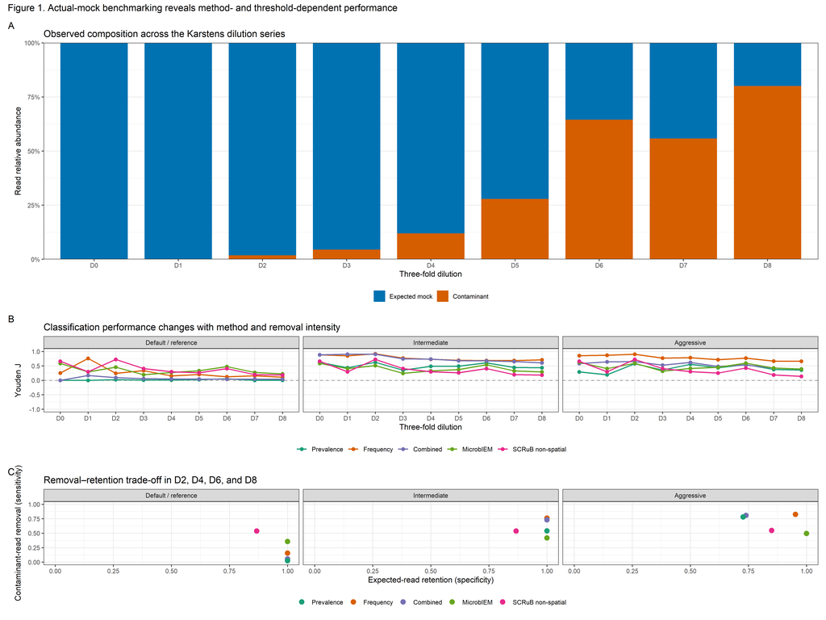

```r
composition_plot <- composition_summary |>
  mutate(
    truth = factor(truth, levels = c("Expected mock", "Contaminant")),
    dilution = factor(SampleID, levels = sample_ids)
  ) |>
  ggplot(aes(dilution, relative_abundance, fill = truth)) +
  geom_col(width = 0.8) +
  scale_fill_manual(values = c("Expected mock" = "#0072B2", "Contaminant" = "#D55E00")) +
  scale_y_continuous(labels = scales::label_percent(), expand = c(0, 0)) +
  labs(
    x = "Three-fold dilution",
    y = "Read relative abundance",
    fill = NULL,
    title = "Observed composition across the Karstens dilution series"
  ) +
  theme(legend.position = "bottom")

youden_plot <- benchmark_metrics |>
  ggplot(aes(dilution, Youden_J, color = method, group = method)) +
  geom_hline(yintercept = 0, color = "grey60", linetype = 2) +
  geom_line(linewidth = 0.8) +
  geom_point(size = 2) +
  facet_wrap(~intensity, nrow = 1) +
  scale_color_manual(values = method_colors) +
  scale_y_continuous(limits = c(-1, 1)) +
  labs(
    x = "Three-fold dilution",
    y = "Youden J",
    color = NULL,
    title = "Classification performance changes with method and removal intensity"
  ) +
  theme(legend.position = "bottom")

tradeoff_plot <- focus_summary |>
  ggplot(aes(mean_Specificity, mean_Sensitivity_Recall, color = method)) +
  geom_point(size = 3) +
  facet_wrap(~intensity, nrow = 1) +
  scale_color_manual(values = method_colors) +
  scale_x_continuous(limits = c(0, 1)) +
  scale_y_continuous(limits = c(0, 1)) +
  labs(
    x = "Expected-read retention (specificity)",
    y = "Contaminant-read removal (sensitivity)",
    color = NULL,
    title = "Removal–retention trade-off in D2, D4, D6, and D8"
  ) +
  theme(legend.position = "bottom")

figure_1 <- composition_plot /
  (youden_plot / tradeoff_plot) +
  patchwork::plot_annotation(
    title = "Figure 1. Actual-mock benchmarking reveals method- and threshold-dependent performance",
    tag_levels = "A"
  )

print(figure_1)
```

```r
ggsave(
  file.path(output_dir, "07_Figure1_Karstens_mock_benchmark.png"),
  figure_1, width = 16, height = 12, dpi = 300
)
ggsave(
  file.path(output_dir, "07_Figure1_Karstens_mock_benchmark.pdf"),
  figure_1, width = 16, height = 12
)
```

# 7 7. Method-by-intensity comparison

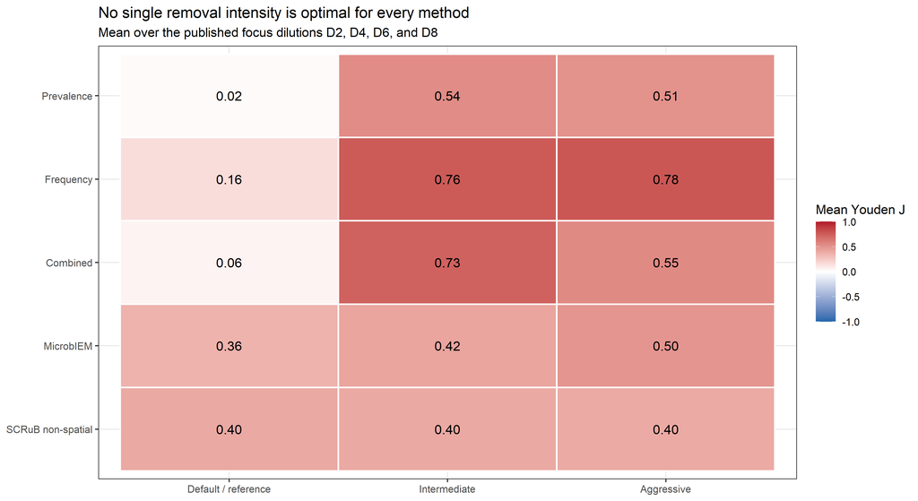

```r
comparison_plot_data <- focus_summary |>
  mutate(
    label = sprintf("%.2f", mean_Youden_J),
    method = factor(method, levels = rev(names(method_colors)))
  )

p_comparison <- ggplot(
  comparison_plot_data,
  aes(intensity, method, fill = mean_Youden_J)
) +
  geom_tile(color = "white", linewidth = 0.7) +
  geom_text(aes(label = label), size = 4) +
  scale_fill_gradient2(
    low = "#2166AC", mid = "white", high = "#B2182B",
    midpoint = 0, limits = c(-1, 1)
  ) +
  labs(
    x = NULL, y = NULL, fill = "Mean Youden J",
    title = "No single removal intensity is optimal for every method",
    subtitle = "Mean over the published focus dilutions D2, D4, D6, and D8"
  )

print(p_comparison)
```

```r
ggsave(
  file.path(output_dir, "07_method_intensity_Youden_heatmap.png"),
  p_comparison, width = 11, height = 6, dpi = 300
)
```

# 8 8. Verification and interpretation boundary

```r
verification <- data.frame(
  check = c(
    "Official dataset contains 10 samples and 1414 ASVs",
    "Gold standard contains 9 expected and 1405 contaminant ASVs",
    "Five methods and three intensity levels completed",
    "Every method-intensity combination produced all nine dilution results",
    "Confusion matrices recover every original sample read",
    "All reported metrics are within their valid ranges"
  ),
  passed = c(
    nsamples(ps) == 10L & ntaxa(ps) == 1414L,
    sum(!truth_table$is_contaminant) == 9L & sum(truth_table$is_contaminant) == 1405L,
    n_distinct(benchmark_metrics$method) == 5L &
      n_distinct(benchmark_metrics$intensity) == 3L,
    nrow(benchmark_metrics) == 5L * 3L * 9L,
    all(
      benchmark_metrics$TP + benchmark_metrics$TN +
        benchmark_metrics$FP + benchmark_metrics$FN ==
        rowSums(count_matrix[as.character(benchmark_metrics$SampleID), , drop = FALSE])
    ),
    all(benchmark_metrics$Sensitivity_Recall >= 0 & benchmark_metrics$Sensitivity_Recall <= 1) &
      all(benchmark_metrics$Specificity >= 0 & benchmark_metrics$Specificity <= 1) &
      all(benchmark_metrics$Precision_PPV >= 0 & benchmark_metrics$Precision_PPV <= 1) &
      all(benchmark_metrics$F1 >= 0 & benchmark_metrics$F1 <= 1) &
      all(benchmark_metrics$Youden_J >= -1 & benchmark_metrics$Youden_J <= 1)
  )
)

write_csv(verification, file.path(output_dir, "07_06_verification.csv"))
knitr::kable(verification)
```

| check | passed |
| --- | --- |
| Official dataset contains 10 samples and 1414 ASVs | TRUE |
| Gold standard contains 9 expected and 1405 contaminant ASVs | TRUE |
| Five methods and three intensity levels completed | TRUE |
| Every method-intensity combination produced all nine dilution results | TRUE |
| Confusion matrices recover every original sample read | TRUE |
| All reported metrics are within their valid ranges | TRUE |

```r
if (!all(verification$passed)) stop("One or more benchmark checks failed.")
```

This even mock is a controlled benchmark, not a universal threshold selector. It tests preservation of nine known ASVs under a biomass gradient. A threshold that performs well here may still remove genuine inhabitants in a real skin or other low-biomass dataset. The next validation layer should therefore combine negative-control enrichment with explicit retention of literature-supported commensal genera before a threshold is accepted for biological analysis.